13/11/2019

## Introduction

## Last time

- External pilot trial followed by a definitive trial
- Both trials to be analysed using a hypothesis test
- Needed to choose type I and II error rates \(\alpha_i, \beta_i, i=1,2\) at each stage
- Proposed to choose the rates which maximised expected utility, w.r.t. a prior distribution

## Maximising expected utility

- Rather than making a stop/go decision at the pilot stage through a hypothesis test, we could instead use MEU
- Given pilot data \(x_1\), get the posterior \(\mu | x_1\) and choose \(\alpha_2, \beta_2\)
- Simplify: fix \(\alpha_2 = 0.025\), so just need to choose \(\beta_2\) or, equivalently, the definitive sample size \(n_2\)
- With this analysis in mind, how large should the pilot be?

## MEU

Given pilot data \(x_1\) from a pilot of sample size \(n_1\): \[ \max_{n_2} ~\mathbb{E}_{\mu, x_2 | x_1, n_1}\big[u(n_1, n_2. x_2)\big] \]

## MEU

Given a pilot of sample size \(n_1\), average over the pilot data \(x_1\): \[ \mathbb{E}_{x_1 | n_1} \Big( \max_{n_2} ~\mathbb{E}_{\mu, x_2 | x_1, n_1}\big[u(n_1, n_2. x_2)\big] \Big) \]

## MEU

Find optimal pilot sample size \(n_1\): \[ \max_{n_1} \Bigg[ ~\mathbb{E}_{x_1 | n_1} \Big( \max_{n_2} ~\mathbb{E}_{\mu, x_2 | x_1, n_1}\big[u(n_1, n_2. x_2)\big] \Big) \Bigg] \]

## Computation

## Nested MC

\[ \max_{n_1} \Bigg[ ~\mathbb{E}_{x_1 | n_1} \Big( \max_{n_2} ~\mathbb{E}_{\mu, x_2 | x_1, n_1}\big[u(n_1, n_2. x_2)\big] \Big) \Bigg] \]

- \(\max_{n_1}\) - exhaustive / binary / other search
- \(\mathbb{E}_{x_1 | n_1}\) - sample \(N\) pilot data \(x_1^{(i)} \sim p(x_1, | n_1)\)
- \(\max_{n_2}\) - exhaustive / binary / other search
- \(\mathbb{E}_{\mu, x_2 | x_1, n_1}\) - sample \(M\) posterior parameters \(\mu^{(j)} \sim p(\mu | x_1, n_1)\)

Extremely computationaly intensive.

## An alternative

Note that the inner optimisation problem maps pilot data \(x_1\) to definitive sample size \(n_2\). \[ f(x_1): \mathcal{X_1} \rightarrow \mathbb{N} \] Ignoring optimising over \(n_1\) for now, we can re-write our eearlier expression: \[ \mathbb{E}_{x_1 | n_1} \Big(\mathbb{E}_{\mu, x_2 | x_1, n_1}\big[u(n_1, \textcolor{red}{n_2 = f(x_1)}, x_2)\big] \Big) = \mathbb{E}_{\mu, x_1} \Big(\mathbb{E}_{x_2 | \mu, x_1, n_1}\big[u(n_1, \textcolor{red}{f(x_1)}, x_2)\big] \Big) \]

## Single-level MC

\[ \mathbb{E}_{x_1 | n_1} \Big( \max_{n_2} ~\mathbb{E}_{\mu, x_2 | x_1, n_1}\big[u(n_1, n_2. x_2)\big] \Big) \geq \mathbb{E}_{\mu, x_1} \Big(\mathbb{E}_{x_2 | \mu, x_1, n_1}\big[u(n_1, f(x_1), x_2)\big] \Big) ~ \text{ for all } f. \]

- \(\mathbb{E}_{\mu, x_1}\) - sample \(N\) \((\mu^{(i)}, x_1^{(i)}) \sim p(\mu, x_1 | n_1) = p(x_1 | \mu, n_1)p(\mu)\)
- \(\mathbb{E}_{x_2 | \mu, x_1, n_1}\) - analytic if the power function is known

If we can search over functions \(f(x_1)\) and ind the optimal decision rule, this will coincide with the actual MEU rule.

## Splines

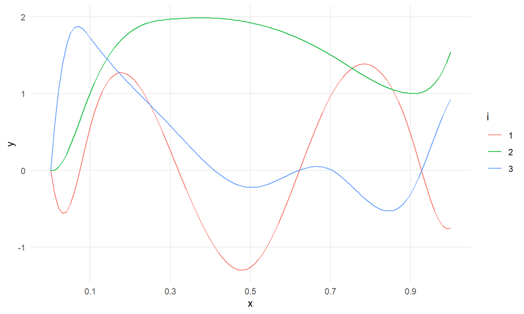

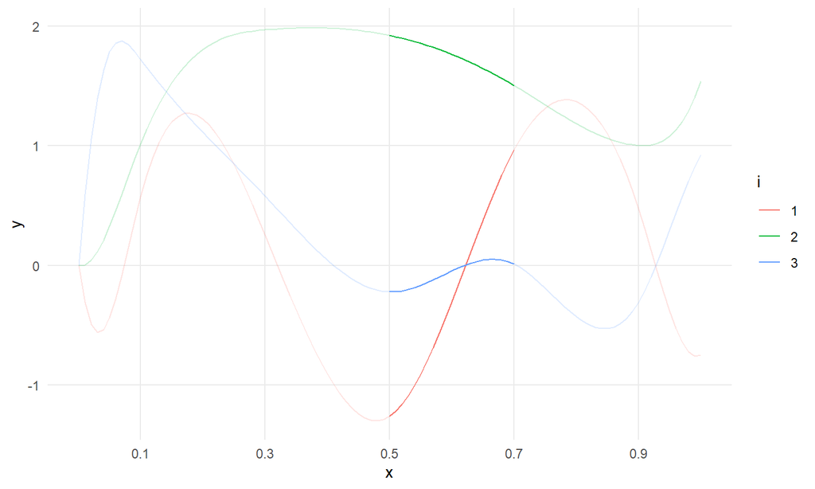

## B-splines

For some knots \(x_1^{(1)}, \ldots , x_1^{(N)}\) we can obtain the the set of cubic splines which serve as a basis for the space of all cubic splines defined over the same knots. Denoting these so-called b-splines by \(\phi_i(x_1), k=1,\ldots,k+4\), a decision rule is then \[ d(x_1) = \left\lfloor \sum_{i=1}^{k+4} a_i \phi_i(x_1) \right\rfloor, \]

Optimisation is then over the vector of coefficients \((a_1, a_2, \ldots, a_{k+4}\).

## B-splines

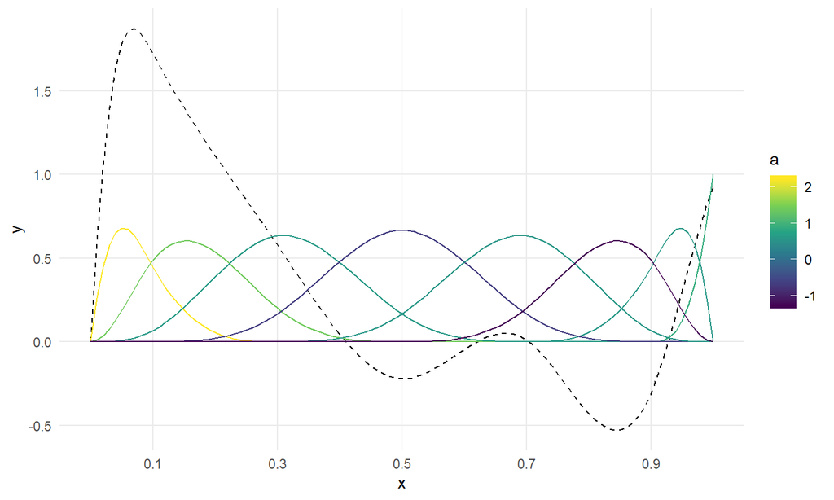

## Example

[output not shown]

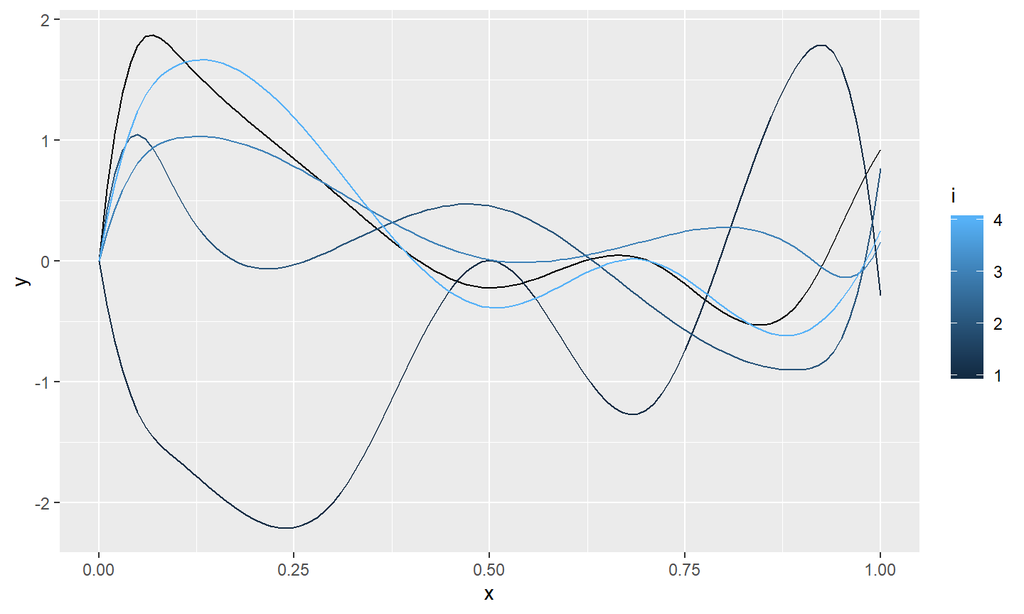

## Introduction

“What is the principal distinction between Bayesian and classical statistics? It is that Bayesian statistics is fundamentally boring. There is so little to do: just specify the model and the prior, and turn the Bayesian handle” - Phil Dawid commenting on Lindley’s The Philosophy of Staistics (2000)

Not just prior and model, but utility, and we can make any decision optimally.

Two major challenges in practice: - specifying a utility (assuming model and prior are correct) - doing the calculations

We will consider a specific problem in clinical trial design, and attempt to say something interesting about each of these challenges.

### Motivation

- Assessing effectiveness in complex intervention pilot trials to improve efficiency
- Testing not advised due to low power, an artefact of sharing the same endpoint and small pilot sample
- Not testing at all is never optimal, and probably never done in practice
- How do we choose optimal pilot error rates?

### BSDT

- Provides one way to define optimality
- (assume model and prior are given)
- utility and computations

## Part 1

### Problem

- Pilot and definitive trial, shared normal endpoint, known variance, unknown effect, two-arm etc.
- Normal conjgate prior on effect
- Make progression decision at each stage using a z-test of means
- Programme design defined by ns and cs at each stage

### Optimisation

- Search over the four parameters to maximise expected utility

### MEU theory

- Doing MEU is not a hueristic, but axiomatic
- Given some basic axioms about our preferences and how we want to behave (coherence), there exists a utility function s.t. preferences between distributions is encoded by its expectation
- Need to be able to find this specific utility, which means asking the right questions
- Contrast with ad-hoc “utilities”, e.g. Thall

### Attributes

- First need to identify the things that we have preferences about
- Average change in outcome in the population
- Sample size at each stage
- “treatment costs” (known and deterministic)
- Attribute space

### Value

- Preferences in the attribute space under certainty
- Complete and transitive
- Looking for a value function which encodes preferences
- Introduce some structure, sum of single attribute functions (equivalent to assuming mutal preferential independance)
- More stucture, linearity in each single attribute function (implications)
- Need to dtermine three parameters, scaled, so two questions

### Utility

- Preference in the attribute space under uncertainty, so preferences over distributions
- All utility functions are value functions (just apply to degnerative dists), but not the converse
- Make an assumption that one attribute is utility independant of the other two (implications)
- Handy result, utility function must have exponential form, just one more parameter desribing risk attitude, one more question to elicit
- Note any additive utility implies all the above and risk-neutraility, and almost all utilities in the literature are additive

### Expected utility

- Condition on effect, closed form if we have a power function
- Integrate out effect, fast G-H quadrature since normal prior

### Application - OK-Diabetes

- Guess prior and utility parameters
- Compare optimal design with one constrained to not test in pilot
- sensitivity to prior and utility parameters

### Evaluation

- Optimal programmes for a range of utilities
- Testing in the pilot always optimal, but generally with high type I rate
- If we are sufficiently risk seeking, reduce to one stage design

### Extensions

- Internal pilot
- More complex designs and models, e.g. unknown variance or binary outcome
- More complex utilities, e.g. more attributes

## Part 2

### Problem

- If we have set up our utility, we can analyse the pilot through MEU
- Assume definitive type I set at default
- Now just need to choose the pilot sample size

### Nested MC algorithm

- Simple
- Computationally demanding
- Automating Bayesain inference without checks

### Surrogate decision rules

- Re-casting the problem as searching over rules mapping pilot data to definitive sample sizes
- Need a way to represent functions and search over them

### Splines

- Defined by their order and their knots
- Some example functions for a given set of knots
- Basis function representation

### Optimisation

- Add stop/go component
- incorportae a search over pilot n

### Application - OK-Diabetes

- Semi-analytic solution
- Nested MC
- Surrogate decision rules

### Limitations and alternatives

- EVSI (including regression based) focussed on few decisions
- GAM approach limited to one or two dimensions of pilot sample space
- Moment matching might be better, artificually restricting set of decisions

### Extensions

- Optimising defnitive trial alpha
- Internal pilots
- More complex designs and models, e.g. unknown variance or binary outcome
- More complex utilities, e.g. more attributes